# 第14回 年代とジャンルを、1枚の地図に

## 前回からの接続

前回は、職業訓練を受けた人と受けなかった人の年収を比べました。その差が偶然でも出るかを、ラベルを並べ替えて確かめました（並べ替え検定）。

前回比べたのは、年収という数の列でした。今日のデータには、数の列がありません。映画の公開の年代と、ジャンルという、2つの区分だけです。区分と区分の表から、どの年代にどのジャンルが多いかを、1枚の地図で読みます。並べ替え検定（permutation test）も、もう一度使います。

## 今日の分析目標

あなたは映画配信サービスの企画担当です。年代別の特集に、どのジャンルを合わせればよいかに答える。

映画の一覧から、ジャンルと年代の表（クロス表）を作ります。年代によってジャンルが偏っているかを確かめ、偏りを対応分析（correspondence analysis）で1枚の地図にし、倍率の表で確かめます。

もう1つのねらいは、これまでの書き方を組み合わせて、データの読み込みから報告の一文まで、1本の分析を自分で通せるようになることです。最後の「目標に答えられたか」で振り返りましょう。

### 場面

あなたは、映画配信サービスの企画担当です。古い映画から新しい映画まで、たくさんの作品を扱っています。次の企画は「年代別の特集」です。

決めたいのは、それぞれの年代の特集に、どのジャンルを並べるかです。その時代らしさが出る組み合わせを、根拠をもって選びたいところです。

### 手元のデータ

MovieLens（Harper & Konstan, 2015）の映画の一覧（ml-latest-small）です。ミネソタ大学の研究グループGroupLensが、研究と教育のために公開しています。再配布は認められていないので、ノートの中でGroupLensのページから取ってきます。

1行が1本の映画です。題名の後ろのかっこに公開年が、ジャンルの列に「|」で区切った複数のジャンルが入っています。答えの列はありません。

### 最後に出す答え

年代ごとに、合わせるジャンルを並べた企画の一文です。その根拠として、1枚の地図と、その年代に多いジャンルを示す倍率を出します。

## 学習ゴール

この回を終えると、次のことができるようになります。

- 1行1本の一覧から、区分と区分のクロス表（contingency table）を作れる。重ねて数えていないかを確かめられる
- 期待度数（expected frequency）とカイ二乗統計量（chi-squared statistic）を計算し、偏りが偶然でも出るかを、並べ替え検定で確かめられる
- 標準化残差（standardized residual）の表を特異値分解（singular value decomposition）で縮め、行と列を1枚の地図に置いて、寄与率（proportion of variance explained）を読める
- 地図の読みを、実際の本数と期待度数の倍率で確かめられる
- これまでの書き方（`def`、`for`、辞書、f-string）を組み合わせて、分析を最後まで書ける

## 0. 準備

### 最初に実行する：道具を呼び出す

- 役割：このノートで使う道具（ライブラリ）を呼び出す
- 入力：なし
- 出力：なし（終わるとセルの左に ✓ が付く）

```python
import numpy as np
import pandas as pd
import matplotlib.pyplot as plt
```

### 図の日本語を表示できるようにする

- 役割：図の中の日本語が □ にならないようにし、図の大きさと字の大きさをそろえる
- 入力：なし
- 出力：「セットアップ完了」の表示

`try:`から先は、日本語表示の道具が動かなくなったときの保険で、中身は読まなくてかまいません。

```python
# 日本語が図の中で □ になるのを防ぐ
!pip install -q japanize-matplotlib
try:
    import japanize_matplotlib
# japanize が動かなくなったときの保険：同梱フォントを直接登録する
except Exception:
    from importlib.util import find_spec
    from matplotlib import font_manager as fm
    from pathlib import Path
    spec = find_spec('japanize_matplotlib')
    ttf = None
    if spec:
        ttf = next(Path(spec.origin).parent.rglob('*.ttf'), None)
    if ttf:
        fm.fontManager.addfont(str(ttf))
        name = fm.FontProperties(fname=str(ttf)).get_name()
        plt.rcParams['font.family'] = name

plt.rcParams['figure.figsize'] = (7, 5)
plt.rcParams['font.size'] = 13
plt.rcParams['axes.unicode_minus'] = False  # マイナス記号の化けを防ぐ
print('セットアップ完了')
```

```
セットアップ完了
```

### 映画の一覧を、取ってくる

- 役割：GroupLensのページから、映画の一覧（zip）を取ってきて、展開する
- 入力：zipの場所（URL）
- 出力：展開したフォルダの中身
- `urllib.request.urlretrieve(URL, 保存先)`は、URLのファイルを保存します
- `shutil.unpack_archive(zip, 展開先)`は、zipを展開します
- `os.path.exists`で、まだ取ってきていないときだけ取ってきます（第12回）

```python
import os
import shutil
import urllib.request
WORK = '/content'   # Colab の作業場所
URL = ('https://files.grouplens.org/datasets/movielens/'
       'ml-latest-small.zip')
if not os.path.exists(f'{WORK}/ml-latest-small'):   # まだなら
    urllib.request.urlretrieve(URL, f'{WORK}/ml.zip')
    shutil.unpack_archive(f'{WORK}/ml.zip', WORK)
print(sorted(os.listdir(f'{WORK}/ml-latest-small')))
```

```
['README.txt', 'links.csv', 'movies.csv', 'ratings.csv', 'tags.csv']
```

5つのファイルが入っています。今日使うのは、映画の一覧`movies.csv`だけです。評価の記録（`ratings.csv`）などは使いません。

### 今日の道筋

次の6つの小さな問いに答えていきます。

1. ジャンルと年代の表を、どう作るか？（1節）
2. 年代によって、ジャンルは偏っているか？（2節）
3. その偏りは、偶然でも出るか？（3節）
4. 偏りの表を、どう1枚の地図に縮めるか？（4節）
5. 地図の読みは、倍率で確かめられるか？（5節）
6. 年代別の特集に、何を合わせるか？（6節）

## 1. ジャンルと年代の表を、どう作るか？

映画の一覧が手に入りました。まず一覧を読み、ジャンルと年代の表を作ります。

### お手本：映画の一覧を読む

- 役割：映画の一覧を読み、大きさと先頭の3本を表示する
- 入力：ファイルの場所
- 出力：表の大きさと、先頭の3本

```python
mv = pd.read_csv(f'{WORK}/ml-latest-small/movies.csv')
print(mv.shape)
mv.head(3)
```

```
(9742, 3)
```

|  | movieId | title | genres |
| --- | --- | --- | --- |
| 0 | 1 | Toy Story (1995) | Adventure\|Animation\|Children\|Comedy\|Fantasy |
| 1 | 2 | Jumanji (1995) | Adventure\|Children\|Fantasy |
| 2 | 3 | Grumpier Old Men (1995) | Comedy\|Romance |

9742本の映画です。`title`の後ろのかっこに公開年が、`genres`に「|」で区切ったジャンルが入っています。1本目の『Toy Story』には、5つのジャンルが付いています。

年代で数えるには、題名から公開年を取り出す必要があります。

### 新しい書き方：文字の中から、数字を取り出す

`str.extract(型)`は、文字の列から、型に合う部分を取り出します。型は、正規表現（regular expression）という書き方で書きます。今日使う型は、次の1つだけです。

- `r'\((\d{4})\)'`：かっこの中の4けたの数字
- `\(`と`\)`は、かっこの文字そのもの。`\d{4}`は4けたの数字
- 内側の`( )`で囲んだ部分（4けたの数字）を、取り出す

結果は表で返るので、`[0]`で1列目を取り出します。

```python
s = pd.Series(['Toy Story (1995)', 'Heat (1995)', 'Up'])
s.str.extract(r'\((\d{4})\)')[0]
```

```
0    1995
1    1995
2     NaN
Name: 0, dtype: object
```

型に合わない`'Up'`は、`NaN`（欠測値）になりました。

### お手本：公開年を取り出す

- 役割：題名から公開年を取り出して`年`の列にし、取り出せなかった映画を数える
- 入力：表`mv`
- 出力：取り出せなかった本数と、いちばん古い年・新しい年

```python
mv['年'] = mv['title'].str.extract(r'\((\d{4})\)')[0]
print(mv['年'].isna().sum())
mv = mv.dropna(subset=['年'])
mv['年'] = mv['年'].astype(int)
print(mv['年'].min(), mv['年'].max())
```

```
13
1902 2018
```

13本は、題名に公開年がありませんでした。`dropna(subset=['年'])`で、`年`が欠測（missing data）の行を除きます（第6回）。残りの映画は、1902年から2018年までです。

### お手本：10年ごとの年代にする

- 役割：公開年を10年ごとの年代（1995年なら1990）にし、年代ごとの本数を数える
- 入力：表`mv`
- 出力：年代ごとの本数

`//`は、割り算の商（小数点以下を切り捨てた答え）です。`1995 // 10`は199で、それに10を掛けると1990になります。

```python
mv['年代'] = mv['年'] // 10 * 10
mv['年代'].value_counts().sort_index()
```

```
年代
1900       3
1910       7
1920      37
1930     136
1940     197
1950     279
1960     401
1970     500
1980    1177
1990    2212
2000    2849
2010    1931
Name: count, dtype: int64
```

1920年代までは、3本・7本・37本しかありません。本数が少なすぎると、割合が大きく揺れるので、1930年代から2010年代までの9つの年代を使います。2010年代は、2018年までの映画です。

```python
m = mv[mv['年代'] >= 1930].copy()
print(len(m))
```

```
9682
```

9682本です。`.copy()`は、絞った表を別の表として作ります（第12回）。このあと`m`に列を足すので、元の`mv`と切り離しておきます。

### 新しい書き方：1行を、ジャンルごとの行に分ける

ジャンルは「|」で区切って1つの文字に入っています。これを、1行に1つのジャンルの形に直します。

- `str.split('|')`は、文字を「|」で区切って、リストにします
- `explode('列')`は、リストの入った列を、要素ごとの行に分けます。ほかの列は、同じ値を写します。行の番号（インデックス）も、元の行の番号のままです

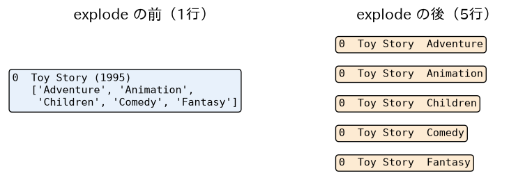

### お手本：ジャンルを1行1つに分ける

- 役割：ジャンルをリストにし、1行1ジャンルの表`e`を作る
- 入力：表`m`
- 出力：`m`と`e`の行の数と、`e`の先頭の6行

```python
m['ジャンル'] = m['genres'].str.split('|')
e = m.explode('ジャンル')
print(len(m), len(e))
e[['title', '年代', 'ジャンル']].head(6)
```

```
9682 21972
```

|  | title | 年代 | ジャンル |
| --- | --- | --- | --- |
| 0 | Toy Story (1995) | 1990 | Adventure |
| 0 | Toy Story (1995) | 1990 | Animation |
| 0 | Toy Story (1995) | 1990 | Children |
| 0 | Toy Story (1995) | 1990 | Comedy |
| 0 | Toy Story (1995) | 1990 | Fantasy |
| 1 | Jumanji (1995) | 1990 | Adventure |

9682行が、21972行になりました。『Toy Story』は5行に分かれ、5行とも行の番号は0のままです。

### お手本：多い10ジャンルに絞る

- 役割：ジャンルごとの行の数を数え、多い10ジャンルに絞る
- 入力：表`e`
- 出力：多い10ジャンルとその数

`isin(リスト)`は、リストのどれかに当てはまる行で`True`になります（第10回）。

```python
top = e['ジャンル'].value_counts().index[:10]
e = e[e['ジャンル'].isin(top)]
print(e['ジャンル'].value_counts())
```

```
ジャンル
Drama        4340
Comedy       3737
Thriller     1890
Action       1822
Romance      1586
Adventure    1256
Crime        1196
Horror        973
Sci-Fi        973
Fantasy       771
Name: count, dtype: int64
```

ドラマ（Drama）とコメディ（Comedy）が多く、ファンタジー（Fantasy）までの10ジャンルを使います。

### おさらい：pd.crosstab

`pd.crosstab(行にする列, 列にする列)`は、2つの区分の組み合わせごとに、行の数を数えた表（クロス表）を作ります（第11回）。

```python
pd.crosstab(pd.Series(['A', 'A', 'B']), pd.Series([1, 2, 2]))
```

| col_0 row_0 | 1 | 2 |
| --- | --- | --- |
| A | 1 | 1 |
| B | 0 | 1 |

### お手本：ジャンルと年代のクロス表

- 役割：ジャンル（行）と年代（列）のクロス表`ct`を作る
- 入力：表`e`
- 出力：10行9列のクロス表

```python
ct = pd.crosstab(e['ジャンル'], e['年代'])
ct
```

| 年代 ジャンル | 1930 | 1940 | 1950 | 1960 | 1970 | 1980 | 1990 | 2000 | 2010 |
| --- | --- | --- | --- | --- | --- | --- | --- | --- | --- |
| Action | 8 | 8 | 15 | 56 | 103 | 227 | 392 | 549 | 464 |
| Adventure | 13 | 13 | 30 | 65 | 71 | 170 | 239 | 363 | 292 |
| Comedy | 53 | 55 | 67 | 132 | 155 | 492 | 890 | 1135 | 758 |
| Crime | 15 | 29 | 29 | 43 | 70 | 124 | 264 | 404 | 218 |
| Drama | 74 | 118 | 146 | 192 | 225 | 439 | 1038 | 1365 | 743 |
| Fantasy | 8 | 11 | 11 | 25 | 31 | 106 | 149 | 252 | 178 |
| Horror | 9 | 12 | 25 | 40 | 63 | 176 | 160 | 298 | 190 |
| Romance | 48 | 54 | 64 | 60 | 44 | 154 | 422 | 523 | 217 |
| Sci-Fi | 3 | 2 | 35 | 35 | 59 | 156 | 173 | 266 | 244 |
| Thriller | 11 | 32 | 32 | 49 | 95 | 180 | 420 | 654 | 417 |

1つの升が、そのジャンル・その年代の映画の本数です。1930年代のロマンス（Romance）は48本、1940年代のSF（Sci-Fi）は2本です。

### 確かめる：表の合計と、映画の本数

- 役割：表の合計と、表に入った映画の本数（行の番号の種類の数）を比べる。2つ以上の升で数えられた映画の割合も出す
- 入力：`ct`と`e`
- 出力：3つの数

`e`の行の番号は、元の映画の番号のままでした。`nunique()`は、種類の数を返します。

```python
print(ct.to_numpy().sum())
print(e.index.nunique())
print((e.index.value_counts() > 1).mean().round(3))
```

```
18544
9162
0.655
```

表の合計は18544本なのに、表に入った映画は9162本しかありません。65.5%の映画が、2つ以上の升で数えられています。1つの数が1本の別の映画、という表ではありません。

この数え方は、年代ごとのジャンルの割合を見るには困りません。けれども、表の数を「別々の映画の本数」として扱う計算をするときには、注意が要ります。

## 2. 年代によって、ジャンルは偏っているか？

ジャンルと年代のクロス表ができました。では、年代によって、ジャンルの割合は違うのでしょうか。

### 独立なら、何本になるか：期待度数

ジャンルと年代に関係がない（独立）なら、どの年代でも、ジャンルの割合は全体と同じになるはずです。そのとき升に入るはずの本数を、期待度数と呼びます。

$$E_{ij} = \frac{(\text{行}\ i\ \text{の合計}) \times (\text{列}\ j\ \text{の合計})}{\text{総数}\ n}$$

ロマンスは全体の何割かを占めます。1930年代の242本の中にも、同じ割合でロマンスがあるはず、という計算です。

### 新しい書き方：総当たりの掛け算

`np.outer(a, b)`は、`a`の要素と`b`の要素を総当たりで掛けた表を作ります。

```python
np.outer([1, 2], [10, 20, 30])
```

```
array([[10, 20, 30],
       [20, 40, 60]])
```

### お手本：期待度数の表

- 役割：クロス表を配列`O`（観測度数）にし、行の合計・列の合計・総数から、期待度数の表`E`を作る
- 入力：`ct`
- 出力：`E`の大きさと、1930年代のロマンスの期待度数と実際の本数

`sum(axis=1)`は行ごとの合計、`sum(axis=0)`は列ごとの合計です。ロマンスは、上から8行目（番号7）、1930年代は左から1列目（番号0）です。

```python
O = ct.to_numpy()
n = O.sum()
E = np.outer(O.sum(axis=1), O.sum(axis=0)) / n
print(E.shape)
print(O.sum(axis=1)[7], O.sum(axis=0)[0], n)
print(E[7, 0].round(1), O[7, 0])
```

```
(10, 9)
1586 242 18544
20.7 48
```

ロマンスは全部で1586本、1930年代は242本、総数は18544本です。1930年代のロマンスの期待度数は、1586 × 242 ÷ 18544で20.7本です。実際は48本なので、期待の2倍以上あります。

### ずれを、1つの数に集める

升ごとのずれは、本数の多い升ほど大きく出ます。そこで、ずれを期待度数の平方根で割って、そろえます。これを標準化残差と呼びます。

$$z_{ij} = \frac{O_{ij} - E_{ij}}{\sqrt{E_{ij}}}$$

標準化残差の二乗をすべての升で足した数を、カイ二乗統計量と呼びます。ずれが大きいほど、大きくなります。

$$\chi^2 = \sum_{i}\sum_{j} z_{ij}^2$$

### お手本：標準化残差とカイ二乗統計量

- 役割：標準化残差の表`Z`を作り、二乗の和`chi`を出す
- 入力：`O`と`E`
- 出力：1930年代のロマンスの標準化残差と、カイ二乗統計量

```python
Z = (O - E) / np.sqrt(E)
chi = (Z ** 2).sum()
print(Z[7, 0].round(2))
print(chi.round(1))
```

```
6.0
548.4
```

1930年代のロマンスの標準化残差は6.0で、ずれが大きい升です。カイ二乗統計量は548.4です。

### TODO①：scipyで、同じ値になるか確かめる

`scipy.stats`の`chi2_contingency(表)`は、カイ二乗統計量・p値（p-value）・自由度（degrees of freedom）・期待度数の4つを返します。`ct`を渡して、4つを`chi_s, p, dof, E_s`で受け取り、カイ二乗統計量と自由度とp値を表示してください。期待度数が`E`と同じかも、`np.allclose`（第11回）で確かめましょう。

```python
# TODO: chi2_contingency で、カイ二乗統計量と p値を出す
# ヒント: from scipy.stats import chi2_contingency
#         chi_s, p, dof, E_s = chi2_contingency(ct)
#         print(round(chi_s, 1), dof, p)
#         print(np.allclose(E, E_s))
...;
```

カイ二乗統計量は同じ548.4、自由度は72、p値は$10^{-74}$ほどの、とても小さい値です。期待度数も`E`と一致します。

このp値は、式（カイ二乗分布）から求めた値です。その式は、「1つの数が1本の別の映画」という表を前提にしています。1節で見たとおり、この表は65.5%の映画を重ねて数えているので、前提が崩れています。式のp値は、そのままでは使えません。

## 3. その偏りは、偶然でも出るか？

カイ二乗統計量は548.4でした。けれども、式のp値は、この表には使えません。では、この大きさは、偶然でも出るのでしょうか。前回の並べ替え検定で確かめます。

### 映画ごとに、年代を並べ替える

帰無仮説（null hypothesis）は、「ジャンルと年代は関係がない」です。関係がないなら、どの映画がどの年代に作られたかを入れ替えても、表は偶然のずれしか変わらないはずです。

並べ替えるのは、映画ごとの年代です。1本の映画の複数のジャンルは、ひとまとまりのまま動かします。こうすると、重ねて数えることも含めて、元の表と同じ数え方のまま、偶然ならどれくらいのカイ二乗統計量が出るかが分かります。

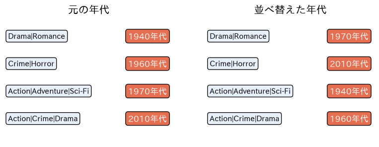

左が元の年代、右が並べ替えた年代です。ジャンルの組はそのままで、年代だけを映画の間で入れ替えます。

### 2回目なので、関数にまとめる

並べ替えるたびに、1節の表づくり（`explode`・絞る・`crosstab`）と、2節のカイ二乗統計量の計算を、やり直します。どちらも2回目なので、関数にまとめます。

- `make_table(m)`：映画の表`m`から、ジャンルと年代のクロス表を作る。1節のセルを並べただけ
- `chi2(ct)`：クロス表から、カイ二乗統計量を出す。2節のセルを並べただけ

```python
def make_table(m):
    e = m.explode('ジャンル')
    e = e[e['ジャンル'].isin(top)]
    return pd.crosstab(e['ジャンル'], e['年代'])


def chi2(ct):
    O = ct.to_numpy()
    E = np.outer(O.sum(axis=1), O.sum(axis=0)) / O.sum()
    return (((O - E) / np.sqrt(E)) ** 2).sum()


obs = chi2(make_table(m))
print(obs.round(1))
```

```
548.4
```

元の表で、2節と同じ548.4になりました。関数にまとめても、手順は変わっていません。

### お手本：1回並べ替える

- 役割：シード0の乱数（random number）生成器で、映画ごとの年代を並べ替えた表`m2`を作り、カイ二乗統計量を出す
- 入力：表`m`
- 出力：並べ替えたときのカイ二乗統計量

`rng.permutation`は、並びをばらばらに並べ替えます（第13回）。`m.copy()`で写しを作ってから、写しの`年代`だけを入れ替えます。

```python
rng = np.random.default_rng(0)
m2 = m.copy()
m2['年代'] = rng.permutation(m['年代'].to_numpy())
print(chi2(make_table(m2)).round(1))
```

```
48.7
```

並べ替えると、カイ二乗統計量は48.7になりました。元の548.4よりずっと小さな値です。

### お手本：1000回並べ替える

- 役割：並べ替えを1000回くり返し、カイ二乗統計量をリスト`perm`にためて配列にする。ヒストグラムを描く
- 入力：表`m`
- 出力：ヒストグラムと、`perm`の平均・最大

1回ごとに表を作り直すので、前回の1万回より少ない1000回にします。少し時間がかかります。

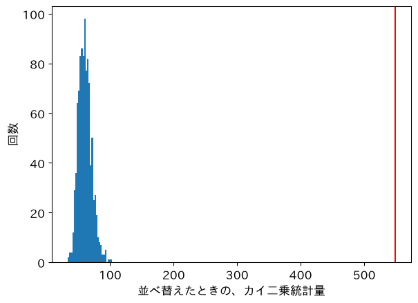

```
60.3 103.0
```

```python
rng = np.random.default_rng(0)
perm = []
for r in range(1000):
    m2 = m.copy()
    m2['年代'] = rng.permutation(m['年代'].to_numpy())
    perm.append(chi2(make_table(m2)))
perm = np.array(perm)
plt.hist(perm, bins=30)
plt.axvline(obs, color='red')
plt.xlabel('並べ替えたときの、カイ二乗統計量')
plt.ylabel('回数')
plt.show()
print(perm.mean().round(1), perm.max().round(1))
```

並べ替えたときのカイ二乗統計量は、平均60.3、いちばん大きくても103.0でした。赤い線の548.4は、山からはるか右に離れています。

### TODO②：548.4以上は、何回出たか

`perm`が`obs`以上になった回数と、その割合（p値）を表示してください。

```python
# TODO: perm が obs 以上になった回数と割合を出す
# ヒント: big = perm >= obs
#         print(big.sum())
#         print(np.mean(big))
...;
```

1000回のうち、0回です。p値は、1000回の並べ替えでは1/1000より小さい、としか言えません。それでも、ジャンルと年代に関係がなければ、548.4のような大きさは、まず出ません。年代によって、ジャンルは偏っています。

結論は式のp値と同じですが、今度は、重ねて数えた表の数え方のまま確かめました。

## 4. 偏りの表を、どう1枚の地図に縮めるか？

偏りは、偶然では出ないと分かりました。では、どのジャンルが、どの年代に偏っているのでしょうか。標準化残差の表`Z`は10行9列、90個の升があり、そのままでは読みきれません。

### 対応分析：ずれの表を、特異値分解で縮める

第9回では、顔の画像の表を、特異値分解で少ない数の向きに縮めました。対応分析は、同じ計算を標準化残差の表`Z`にかけます。

- 特異値分解で、`Z`を「行の向き`U`・特異値（singular value）`d`・列の向き`Vt`」の3つに分ける
- 特異値の二乗の和は、カイ二乗統計量と同じになる
- 特異値の二乗の割合が、その次元で表せるずれの割合（寄与率）になる

この計算の理論は、ここでは扱いません。手順だけを使います。

### おさらい：np.linalg.svd

`np.linalg.svd(表, full_matrices=False)`は、表を`U`・`d`・`Vt`の3つに分けます（第9回）。`d`は、大きい順に並んだ特異値です。

### お手本：標準化残差を、特異値分解する

- 役割：`Z`を特異値分解し、特異値と、その二乗の和を表示する
- 入力：`Z`
- 出力：9個の特異値と、二乗の和

```python
U, d, Vt = np.linalg.svd(Z, full_matrices=False)
print(d.round(2))
print((d ** 2).sum().round(1))
```

```
[19.21  9.55  6.7   4.61  3.69  2.68  1.05  0.53  0.  ]
548.4
```

特異値は9個で、最後は0です。特異値の二乗の和は548.4で、カイ二乗統計量と一致しました。ずれ全体を、9つの次元に分けたことになります。最後が0なのは、ずれ（$O - E$）をどの行で足しても、どの列で足しても0になるので、その分、次元が1つ減るからです。

### TODO③：寄与率を出す

特異値の二乗を、二乗の和で割って、次元ごとの寄与率`share`を表示してください。小数第3位まで丸めましょう。次元1と次元2の寄与率の和も表示します。

```python
# TODO: 次元ごとの寄与率を出す
# ヒント: share = d ** 2 / (d ** 2).sum()
#         print(share.round(3))
#         print(share[:2].sum().round(3))
...;
```

次元1が67.3%、次元2が16.6%で、合わせて83.9%です。2つの次元で、ずれの8割以上を表せます。この2つで、地図を描きます。

### 地図の座標

地図の座標は、`U`と`Vt`の向きに特異値を掛け、行または列の合計の平方根で割って出します。

$$a_i = \frac{U_{i1}\, d_1}{\sqrt{\text{行}\ i\ \text{の合計}}}, \qquad b_j = \frac{V_{j1}\, d_1}{\sqrt{\text{列}\ j\ \text{の合計}}}$$

$a_i$はジャンル$i$の、$b_j$は年代$j$の、次元1の座標です。次元2は、添え字の1を2に変えます。

合計の平方根で割るのは、本数の多いジャンルや年代ほど`Z`が大きく出るので、それを割合の偏りにそろえるためです。こうすると、原点は全体の平均の割合を表し、原点から離れているほど、割合の偏りが大きいことになります。

### お手本：ジャンルと年代の座標

- 役割：ジャンルの座標`g`と、年代の座標`dc`を、次元1・次元2の表にする
- 入力：`U`・`d`・`Vt`と、`O`の行・列の合計
- 出力：2つの表

`Vt[0]`は、`Vt`の1行目（次元1の列の向き）です。

```python
rs = np.sqrt(O.sum(axis=1))   # 行（ジャンル）の合計の平方根
cs = np.sqrt(O.sum(axis=0))   # 列（年代）の合計の平方根
g = pd.DataFrame({'次元1': U[:, 0] * d[0] / rs,
                  '次元2': U[:, 1] * d[1] / rs}, index=ct.index)
dc = pd.DataFrame({'次元1': Vt[0] * d[0] / cs,
                   '次元2': Vt[1] * d[1] / cs}, index=ct.columns)
print(g.round(3))
print(dc.round(3))
```

```
             次元1    次元2
ジャンル
Action    -0.193  0.079
Adventure -0.116 -0.071
Comedy    -0.021  0.017
Crime      0.052  0.026
Drama      0.127 -0.021
Fantasy   -0.106  0.024
Horror    -0.135 -0.165
Romance    0.292 -0.015
Sci-Fi    -0.213 -0.125
Thriller  -0.042  0.120
        次元1    次元2
年代
1930  0.494 -0.095
1940  0.499 -0.000
1950  0.275 -0.234
1960  0.055 -0.126
1970 -0.114 -0.052
1980 -0.136 -0.116
1990  0.093  0.049
2000  0.029  0.034
2010 -0.161  0.033
```

### お手本：地図を描く

- 役割：ジャンル（青い丸）と年代（赤い三角）を、同じ地図に描く
- 入力：`g`と`dc`
- 出力：地図

`plt.text(x, y, 文字)`は、点の位置に名前を書きます。年代は数なので、`str`で文字にします。

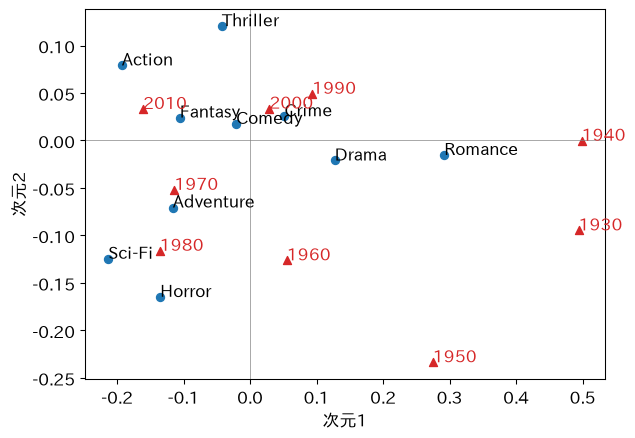

```python
plt.scatter(g['次元1'], g['次元2'], color='tab:blue')
for name in g.index:
    plt.text(g.loc[name, '次元1'], g.loc[name, '次元2'], name)
plt.scatter(dc['次元1'], dc['次元2'], color='tab:red', marker='^')
for dec in dc.index:
    plt.text(dc.loc[dec, '次元1'], dc.loc[dec, '次元2'], str(dec),
             color='tab:red')
plt.axhline(0, color='gray', lw=0.5)
plt.axvline(0, color='gray', lw=0.5)
plt.xlabel('次元1')
plt.ylabel('次元2')
plt.show()
```

ジャンルと年代が、1枚の地図に並びました。地図の符号（右と左）は、計算の道具によって反転することがあります。読むのは、点どうしの並び方です。

## 5. 地図の読みは、倍率で確かめられるか？

地図ができました。この地図を読み、読んだことを、表の数でも確かめます。

### 次元1は、時代の軸

`dc`の次元1を見ると、1930年代（0.494）と1940年代（0.499）が右の端、2010年代（−0.161）・1980年代（−0.136）・1970年代（−0.114）が左にあります。次元1は、おおむね古い年代から新しい年代への軸です。

ジャンルでは、ロマンス（0.292）とドラマ（0.127）が右（古い年代の側）、SF（−0.213）とアクション（−0.193）が左（新しい年代の側）にいます。コメディ（−0.021）は原点の近くで、どの年代にも同じくらいあるジャンルです。

### 確かめる：1990年代が、1960年代より右？

ただし、1990年代（0.093）と2000年代（0.029）は原点のすぐ右にあり、1990年代は1960年代（0.055）より右です。1990年代が1960年代より古い、ということではありません。

- 役割：年代ごとの、表の合計に占める割合を出す
- 入力：`O`と`n`
- 出力：9つの年代の割合

```python
print((O.sum(axis=0) / n).round(3))
```

```
[0.013 0.018 0.024 0.038 0.049 0.12  0.224 0.313 0.201]
```

1990年代が22.4%、2000年代が31.3%で、2つで全体の半分を超えます。原点は全体の平均の割合なので、全体の半分を占める年代の割合は、平均に近くなります。だから、この2つの年代は原点の近くに来ます。

ただし、本数が多ければ原点に近い、とは限りません。2010年代も全体の20.1%を占めますが、左の端にいます。地図の位置を決めるのは、本数ではなく、その年代のジャンルの割合が、全体とどれだけ違うかです。

### お手本：実際 ÷ 期待の倍率

- 役割：各升の、実際の本数を期待度数で割った倍率の表`ratio`を作る
- 入力：`ct`と`E`
- 出力：倍率の表

表を配列で割ると、升ごとに割り算されます。1より大きければ、そのジャンルが、その年代に期待より多いことになります。

```python
ratio = (ct / E).round(2)
ratio
```

| 年代 ジャンル | 1930 | 1940 | 1950 | 1960 | 1970 | 1980 | 1990 | 2000 | 2010 |
| --- | --- | --- | --- | --- | --- | --- | --- | --- | --- |
| Action | 0.34 | 0.24 | 0.34 | 0.82 | 1.14 | 1.04 | 0.96 | 0.96 | 1.27 |
| Adventure | 0.79 | 0.57 | 0.98 | 1.38 | 1.14 | 1.13 | 0.85 | 0.92 | 1.16 |
| Comedy | 1.09 | 0.82 | 0.73 | 0.94 | 0.84 | 1.10 | 1.06 | 0.97 | 1.01 |
| Crime | 0.96 | 1.35 | 0.99 | 0.96 | 1.18 | 0.86 | 0.99 | 1.08 | 0.91 |
| Drama | 1.31 | 1.51 | 1.37 | 1.18 | 1.05 | 0.84 | 1.07 | 1.00 | 0.85 |
| Fantasy | 0.80 | 0.79 | 0.58 | 0.86 | 0.81 | 1.15 | 0.86 | 1.04 | 1.15 |
| Horror | 0.71 | 0.68 | 1.05 | 1.09 | 1.31 | 1.51 | 0.74 | 0.98 | 0.97 |
| Romance | 2.32 | 1.89 | 1.65 | 1.01 | 0.56 | 0.81 | 1.19 | 1.05 | 0.68 |
| Sci-Fi | 0.24 | 0.11 | 1.47 | 0.96 | 1.23 | 1.34 | 0.80 | 0.87 | 1.25 |
| Thriller | 0.45 | 0.94 | 0.69 | 0.69 | 1.02 | 0.79 | 0.99 | 1.10 | 1.10 |

1930年代のロマンスは2.32倍、1940年代のドラマは1.51倍です。1980年代はホラー（Horror）が1.51倍、2010年代はアクション（Action）が1.27倍、SFが1.25倍です。地図で、古い年代の近くにロマンス・ドラマ、新しい年代の近くにアクション・SFがいたことと、合っています。

原点の近くの1990年代と2000年代は、どのジャンルも倍率が1に近く、0.74倍から1.19倍に収まります。

```python
r9 = ratio[[1990, 2000]]
print(r9.min().min(), r9.max().max())
```

```
0.74 1.19
```

### 少ない升は、倍率が大きく揺れる

1940年代のSFは0.11倍で、とても少なく見えます。けれども、1節の表では、この升は2本でした。1本増えるだけで、倍率は半分ほど大きくなります。本数の少ない升の倍率は、大きく揺れます。倍率を読むときは、元の本数も見ます。

### おさらい：forと辞書

空の辞書`{}`を作り、`for`の中で`out[キー] = 値`とすると、キーと値の組を1つずつためられます（第3回）。

```python
out = {}
for k in [1, 2]:
    out[k] = k * 10
print(out)
```

```
{1: 10, 2: 20}
```

### TODO④：1950年代と1970年代の、上位3ジャンル

`for`で1950と1970の2つの年代を取り出し、`ratio`の倍率が高い順に3つのジャンルを、辞書`top3`に`{年代: {ジャンル: 倍率}}`の形でためて表示してください。

```python
# TODO: 1950・1970年代の、倍率の高い3ジャンルを辞書 top3 にためる
# ヒント: top3 = {}
#         for dec in [1950, 1970]:
#             s = ratio[dec].sort_values(ascending=False)
#             top3[dec] = s.head(3).to_dict()
#         print(top3)
...;
```

1950年代は、ロマンス（1.65倍）・SF（1.47倍）・ドラマ（1.37倍）です。1970年代は、ホラー（1.31倍）・SF（1.23倍）・犯罪もの（Crime、1.18倍）です。1950年代にはまだロマンスとドラマが多く、SFが増えはじめています。1970年代には、ホラーとSFが多くなります。地図で、1950年代が右寄り、1970年代が左にあったことと合っています。

## 6. 年代別の特集に、何を合わせるか？

地図の読みを、倍率で確かめられました。最後に、年代ごとの企画の一文を作り、特集に何を合わせるかを答えます。

### おさらい：f-string

`f'…'`の中の`{}`に、変数の値を埋めこめます（第4回）。

```python
n_films = 3
print(f'{n_films}本を選ぶ')
```

```
3本を選ぶ
```

### お手本：1930年代の一文

- 役割：1930年代の倍率を小さい順に並べ、いちばん高いジャンルと、いちばん低いジャンルで一文を作る
- 入力：`ratio`
- 出力：企画の一文

`r.index[-1]`は最後（いちばん高い）のジャンル、`r.iloc[-1]`はその倍率です。

```python
r = ratio[1930].sort_values()
print(f'1930年代は {r.index[-1]}（{r.iloc[-1]}倍）を中心に。'
      f'{r.index[0]}（{r.iloc[0]}倍）は少なめに。')
```

```
1930年代は Romance（2.32倍）を中心に。Sci-Fi（0.24倍）は少なめに。
```

1930年代は、ロマンス（2.32倍）を中心に、SF（0.24倍）は少なめに、という一文になりました。

### TODO⑤：すべての年代の一文

お手本のセルを`for dec in ratio.columns:`の中に入れ、9つの年代のそれぞれについて、同じ形の一文を表示してください。`1930`と書いたところを、`dec`に書き換えます。

```python
# TODO: 9つの年代の、企画の一文を表示する
# ヒント: for dec in ratio.columns:
#             r = ratio[dec].sort_values()
#             print(f'{dec}年代は ...')
...;
```

9つの年代の一文がそろいました。1940年代はロマンス（1.89倍）、1960年代は冒険もの（Adventure、1.38倍）、1980年代はホラー（1.51倍）、2010年代はアクション（1.27倍）が、いちばん高い倍率です。

### 答え

年代別の特集には、次のジャンルを合わせます。

- 1930〜1950年代：ロマンスとドラマ（1930年代のロマンスは2.32倍）
- 1960年代：冒険もの（1.38倍）
- 1970・1980年代：ホラーとSF（1980年代のホラーは1.51倍）
- 2010年代：アクションとSF（1.27倍と1.25倍）
- 1990・2000年代：どのジャンルも倍率が1に近い（0.74倍から1.19倍）。ジャンル以外の切り口を考える
- コメディは、どの年代にも同じくらいある

根拠は3つです。年代によるジャンルの偏りは、映画ごとに年代を並べ替えた1000回で一度も出ない大きさでした（カイ二乗統計量548.4）。対応分析の地図の次元1は時代の軸で、2つの次元でずれの83.9%を表せます。地図の読みは、倍率の表と合っています。

まだ言えないこと

- 作られた本数と、見られる回数は別：数えたのは本数で、視聴の数ではない。特集で視聴が伸びるかは、別のデータで確かめる
- この一覧に入った映画だけ：MovieLensの利用者が評価した映画の一覧で、その時代に作られた映画のすべてではない
- 本数の少ない升：1940年代のSF（2本）のような升の倍率は、大きく揺れる

## 目標に答えられたか

- 今日の目標は「年代別の特集に、どのジャンルを合わせればよいか」でした。どの年代に、どのジャンルを合わせましたか？
- 1節で、表の合計が映画の本数より多くなったのはなぜですか？
- 2節で、期待度数はどう計算しましたか？ カイ二乗統計量は何を測る数ですか？
- 3節で、式のp値ではなく、並べ替え検定で確かめたのはなぜですか？ 何を並べ替えましたか？
- 4節で、特異値の二乗の和は、何と一致しましたか？ 寄与率は何を表しますか？
- 5節で、1990年代と2000年代が原点の近くに来たのはなぜですか？
- 6節で、倍率の高いジャンルを選ぶとき、何に気をつけますか？

## 今日の要点

- 今日、持ち帰る1文：区分と区分の表は、独立なら何本になるか（期待度数）と比べて、ずれを読む。ずれが偶然でないことは、並べ替えで確かめる。ずれの表を特異値分解で縮めると、行と列を1枚の地図に置ける。地図で見えたことは、倍率の表で確かめる
- 表を作ったら、合計と元の本数を比べる。重ねて数えた表では、式のp値の前提が崩れる
- 地図の原点は全体の平均の割合で、原点から離れているほど、割合の偏りが大きい。本数の多さではない
- 本数の少ない升の倍率は、大きく揺れる
- Python：`str.extract`・`str.split`・`explode`で一覧を表にし、`np.outer`で期待度数を作る。並べ替え検定・特異値分解・辞書・f-stringを組み合わせて、分析を最後まで通す

## 次回へ

### 第1〜14回の歩み

今日も、年代別の特集という目標を立て、表を作り、地図と倍率で解析し、企画の答えを出しました。ここまでの14回をふり返ります。題材は自転車・民泊・住宅・心臓病・遺伝子・顔・車・国・銀河・職業訓練・映画とめぐりましたが、どの回も「① データの理解と目標の設定 → ② 前処理（preprocessing）とデータ解析 → ③ 結果の解釈と目標との整合」の一周でした。

| 回 | 分析 | 新しく出てきた書き方 |
| --- | --- | --- |
| 1 | データを見る（自転車） | 列を選ぶ、条件で絞る、集計 |
| 2 | 回帰と汎化（自転車） | numpyの配列、`for`、`if`、行列の計算 |
| 3 | 前処理（東京の民泊） | `def`、条件で値を置き換える |
| 4 | 評価と解釈（民泊・住宅） | 関数を組み合わせる、f-string |
| 5 | 正則化（住宅） | ドキュメントで引数を読む |
| 6 | 分類（心臓病） | 配列の比較と`True`・`False`の集計 |
| 7 | 確率としきい値（心臓病） | クラスとメソッド（`fit`・`predict`） |
| 8 | 教師あり解析を一周（遺伝子） | 関数に分けた1本のスクリプト |
| 9 | 主成分分析（顔） | 行列の計算、特異値分解 |
| 10 | 主成分の地図を読む（車） | 関数に分かれたスクリプトを読む |
| 11 | k-means（国） | `while` |
| 12 | 論文のコードを読む（銀河） | 著者のノートとファイルを読む（JSON・`glob`） |
| 13 | 並べ替え検定とブートストラップ（職業訓練） | 乱数でくり返し、結果をためて分布で読む |
| 14 | 対応分析（映画） | これまでの書き方の総ざらい |

第1〜8回は、正解の列がある分析（当てる・測る・しきい値を決める）でした。第9〜12回と今日は、正解の列がない分析（縮める・分ける・地図にする）でした。第13回と今日の3節では、見えた結果が偶然でも出るかを確かめました。どの回でも、物差しは判断の材料です。最後は目的に照らして答えを出し、「まだ言えないこと」を正直に書く、という姿勢も同じです。

次回は最終回、最終討論です。

これまでの分析から1つを選びます。その分析の「① 目標を立てる → ② 解析する → ③ 目標に立ち返る」の一周と、「まだ言えないこと」を、自分の言葉で説明できるでしょうか。

## 課題（提出）

提出するもの：応用②の答えと、応用③の文章。提出フォームに入力してください。期限はありません。応用①のコードは提出しませんが、②の答えを出すために必要です。

### 応用①（変形）

4節の地図は、1930年代から2010年代までの9つの年代で描きました。古い年代を外し、1990年代以降の3つの年代（1990・2000・2010）に絞ったクロス表`ct2`を作り、同じ手順で特異値分解をして、寄与率と地図を表示してください。

```python
# ここにコードを書く
...;
```

**詰まったら**

`ct2 = ct[[1990, 2000, 2010]]`で3つの列を取り出します。 あとは、2節の`O`・`E`・`Z`と、4節の特異値分解・座標・地図のセルを並べ、`ct`を`ct2`に書き換えます。

### 応用②（判断）

応用①の、次元1の寄与率は何%ですか。%で小数第1位まで答えてください（例: 12.3）。

```python
# ここにコードを書く
...;
```

**詰まったら**

寄与率`d2 ** 2 / (d2 ** 2).sum()`の1つめに100を掛け、`round(…, 1)`します。

### 応用③（解釈）

4節の地図（9つの年代）と、応用①の地図（1990年代以降）を見比べてください。1990年代以降の特集にも、ジャンルで時代らしさを出せるでしょうか。倍率の表も使って、企画担当として3行程度で書いてください。

（ここに3行程度で書く）

## 発展（任意）

### 多重対応分析：区分が3つ以上あるとき

今日の対応分析は、ジャンルと年代という、2つの区分のクロス表を地図にしました。アンケートのように、区分が3つも4つもあるときは、多重対応分析（multiple correspondence analysis, MCA）を使います。

1つの考え方は、それぞれの区分を「その区分なら1」の列（ワンホット、第3回）に直した表を作り、その表に、今日と同じ対応分析をかけることです。1行が1つの個体、1列が1つの区分の値です。

Palmer Penguins（Horstほか, 2020）の、南極の3つの島で測った333羽のペンギンの、種・島・性別の3つの区分で試します。

### お手本：ワンホットの表を作る

- 役割：ペンギンのデータを読み、種・島・性別の3列をワンホットの表`H`にする
- 入力：ペンギンのデータの置き場所
- 出力：`H`の大きさと先頭の3行

`pd.get_dummies`は、区分の列をワンホットの列に直します。`astype(int)`で、`True`・`False`を1・0にします。

```python
# データはこのリポジトリから読み込む
DATA_DIR = ('https://raw.githubusercontent.com/k0heiun0/'
            'applied_exercise_preview/main/shared/data')
pg = pd.read_csv(f'{DATA_DIR}/penguins.csv')
X = pg[['species', 'island', 'sex']].dropna()
H = pd.get_dummies(X).astype(int)
print(H.shape)
H.head(3)
```

```
(333, 8)
```

|  | species_Adelie | species_Chinstrap | species_Gentoo | island_Biscoe | island_Dream | island_Torgersen | sex_Female | sex_Male |
| --- | --- | --- | --- | --- | --- | --- | --- | --- |
| 0 | 1 | 0 | 0 | 0 | 0 | 1 | 0 | 1 |
| 1 | 1 | 0 | 0 | 0 | 0 | 1 | 1 | 0 |
| 2 | 1 | 0 | 0 | 0 | 0 | 1 | 1 | 0 |

### お手本：ワンホットの表に、対応分析をかける

- 役割：`H`を観測度数の表とみなして、2節と4節の手順で、列（区分の値）の座標を出し、地図に描く
- 入力：`H`
- 出力：寄与率と、8つの区分の値の座標、地図

2節・4節のセルと同じ計算です。行は333羽のペンギンなので、地図には列だけを描きます。

```
[0.362 0.289 0.2  ]
                    次元1   次元2
species_Adelie    -0.32  0.92
species_Chinstrap -1.36 -1.16
species_Gentoo     1.16 -0.47
island_Biscoe      0.94 -0.21
island_Dream      -1.10 -0.52
island_Torgersen  -0.39  2.07
sex_Female        -0.02  0.03
sex_Male           0.02 -0.03
```

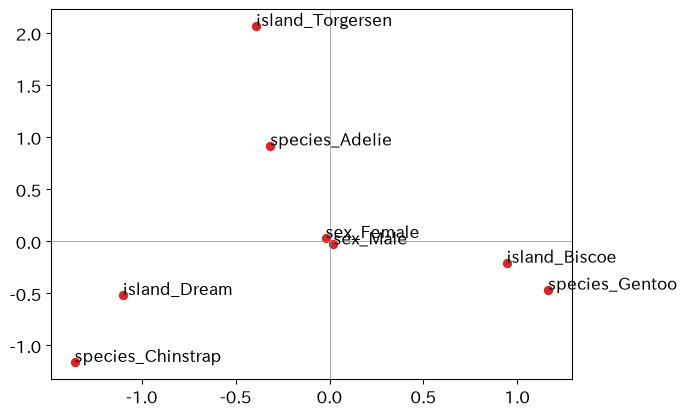

```python
OH = H.to_numpy()
EH = np.outer(OH.sum(axis=1), OH.sum(axis=0)) / OH.sum()
ZH = (OH - EH) / np.sqrt(EH)
UH, dH, VtH = np.linalg.svd(ZH, full_matrices=False)
print((dH ** 2 / (dH ** 2).sum()).round(3)[:3])
csH = np.sqrt(OH.sum(axis=0))
hc = pd.DataFrame({'次元1': VtH[0] * dH[0] / csH,
                   '次元2': VtH[1] * dH[1] / csH}, index=H.columns)
print(hc.round(2))
plt.scatter(hc['次元1'], hc['次元2'], color='tab:red')
for name in hc.index:
    plt.text(hc.loc[name, '次元1'], hc.loc[name, '次元2'], name)
plt.axhline(0, color='gray', lw=0.5)
plt.axvline(0, color='gray', lw=0.5)
plt.show()
```

GentooとBiscoe島が右に、ChinstrapとDream島が左下に、AdelieとTorgersen島が上に並びます。原点から同じ向きに離れた区分の値は、同じ個体に一緒に現れやすい組です。種と島のクロス表で確かめます。

```python
pd.crosstab(X['species'], X['island'])
```

| island species | Biscoe | Dream | Torgersen |
| --- | --- | --- | --- |
| Adelie | 44 | 55 | 47 |
| Chinstrap | 0 | 68 | 0 |
| Gentoo | 119 | 0 | 0 |

GentooはBiscoe島だけ、ChinstrapはDream島だけにいて、Torgersen島にいるのはAdelieだけです。地図の読みと合っています。

性別（`sex_Female`・`sex_Male`）は、どちらの次元も0.03以内で、原点のすぐ近くです。どの種にも、どの島にも、雄と雌が同じくらいいるからです。

ワンホットの表にかけたときの寄与率は、次元1が36.2%と、低めに出ます。ワンホットの表は0と1だけで、1つの区分の中の列どうしは必ず重ならないので、ずれが多くの次元に散らばるからです。寄与率を小さく見積もりすぎないように補正する方法もありますが、ここでは扱いません。

試すなら、`pg['重さ'] = pd.cut(pg['body_mass_g'], 3, labels=['軽', '中', '重'])`で体重を3つの区分にし、4つ目の区分として加えて、地図がどう変わるかを見てみましょう。